# 27회 ADP

park seonga

2023-03-11

### [기계학습]

#### Q1

1.1 EDA 데이터 탐색

```r
data<-read.csv('https://raw.githubusercontent.com/datamanim/datarepo/main/adp/27/problem1.csv')
str(data)
```

```
## 'data.frame':    1193 obs. of  20 variables:
##  $ Time  : num  60 406 426 472 674 ...
##  $ V1    : num  1.069 -2.312 -1.932 -3.044 -0.719 ...
##  $ V2    : num  0.0438 1.952 1.7246 -3.1573 0.639 ...
##  $ V3    : num  0.31 -1.61 1.288 1.088 0.686 ...
##  $ V4    : num  1.3167 3.9979 -0.397 2.2886 -0.0232 ...
##  $ V5    : num  -0.462 -0.522 -0.14 1.36 2.318 ...
##  $ V6    : num  -0.858 -1.427 2.471 -1.065 3.872 ...
##  $ V7    : num  0.208 -2.537 -1.865 0.326 -0.313 ...
##  $ V8    : num  -0.1913 1.3917 -5.1869 -0.0678 1.0898 ...
##  $ V9    : num  0.0564 -2.7701 0.7948 -0.271 -0.5969 ...
##  $ V10   : num  0.04157 -2.77227 0.15538 -0.83859 -0.00614 ...
##  $ V11   : num  -0.5074 3.202 0.0345 -0.4146 -0.2429 ...
##  $ V12   : num  -0.109 -2.9 0.907 -0.503 -0.384 ...
##  $ V13   : num  -0.4733 -0.5952 -0.0272 0.6765 0.1091 ...
##  $ V14   : num  0.452 -4.289 -0.404 -1.692 0.188 ...
##  $ V15   : num  1.006 0.39 -0.474 2.001 1.823 ...
##  $ V16   : num  0.185 -1.141 0.274 0.667 0.274 ...
##  $ V17   : num  -0.44 -2.83 -0.222 0.6 -0.698 ...
##  $ Amount: num  89.4 0 16.2 529 22 ...
##  $ Class : int  0 1 0 1 0 0 0 0 0 0 ...
```

```r
#y=class를 명목형으로 변환
data[,20] <- as.factor(data$Class)
summary(data)
```

```
##       Time              V1                 V2                 V3
##  Min.   :    60   Min.   :-30.5524   Min.   :-33.6446   Min.   :-31.1037
##  1st Qu.: 50265   1st Qu.: -1.3026   1st Qu.: -0.4354   1st Qu.: -1.6093
##  Median : 81797   Median : -0.3025   Median :  0.2320   Median : -0.2342
##  Mean   : 91514   Mean   : -0.7550   Mean   :  0.5437   Mean   : -1.1482
##  3rd Qu.:136995   3rd Qu.:  1.2500   3rd Qu.:  1.1120   3rd Qu.:  0.8115
##  Max.   :172676   Max.   :  2.3206   Max.   : 19.1672   Max.   :  3.3247
##        V4                V5                  V6                 V7
##  Min.   :-4.2949   Min.   :-22.10553   Min.   :-10.8868   Min.   :-37.06031
##  1st Qu.:-0.6103   1st Qu.: -0.84218   1st Qu.: -1.0179   1st Qu.: -0.80604
##  Median : 0.3276   Median : -0.07362   Median : -0.3796   Median : -0.08498
##  Mean   : 0.7778   Mean   : -0.40918   Mean   : -0.2840   Mean   : -0.85254
##  3rd Qu.: 1.3353   3rd Qu.:  0.68422   3rd Qu.:  0.3024   3rd Qu.:  0.46455
##  Max.   :12.1147   Max.   : 15.27576   Max.   :  6.2685   Max.   :  8.12359
##        V8                  V9                V10                V11
##  Min.   :-37.35344   Min.   :-11.1266   Min.   :-23.2283   Min.   :-2.6516
##  1st Qu.: -0.21933   1st Qu.: -1.0397   1st Qu.: -0.8838   1st Qu.:-0.6014
##  Median :  0.07304   Median : -0.2105   Median : -0.2265   Median : 0.2831
##  Mean   :  0.14503   Mean   : -0.4464   Mean   : -0.9043   Mean   : 0.6563
##  3rd Qu.:  0.45479   3rd Qu.:  0.4526   3rd Qu.:  0.2873   3rd Qu.: 1.2122
##  Max.   : 20.00721   Max.   :  5.9168   Max.   :  7.1359   Max.   :11.6692
##       V12                 V13                V14                 V15
##  Min.   :-17.22866   Min.   :-2.80015   Min.   :-18.49377   Min.   :-4.49894
##  1st Qu.: -0.96731   1st Qu.:-0.69256   1st Qu.: -0.95023   1st Qu.:-0.54959
##  Median : -0.01405   Median : 0.02301   Median : -0.09906   Median : 0.04689
##  Mean   : -1.01418   Mean   : 0.01197   Mean   : -1.16835   Mean   : 0.01923
##  3rd Qu.:  0.51212   3rd Qu.: 0.69974   3rd Qu.:  0.41919   3rd Qu.: 0.66062
##  Max.   :  3.10665   Max.   : 3.06823   Max.   :  3.88638   Max.   : 2.86942
##       V16                 V17               Amount        Class
##  Min.   :-14.12985   Min.   :-25.1628   Min.   :   0.00   0:993
##  1st Qu.: -0.70150   1st Qu.: -0.6823   1st Qu.:   3.54   1:200
##  Median : -0.05583   Median : -0.1526   Median :  20.99
##  Mean   : -0.62953   Mean   : -1.0707   Mean   :  88.89
##  3rd Qu.:  0.45814   3rd Qu.:  0.3683   3rd Qu.:  77.49
##  Max.   :  3.13966   Max.   :  6.7394   Max.   :3335.73
```

✓ 총 1193관측치, 19개 종속변수  
1. Time 변수: 해당 거래가 발생한 시간  
2. Amount 변수: 해당 거래의 금액  
3. Class변수: 0(정상거래): 993건, 1(사기거래): 200건  
✓ 결측치는 없음

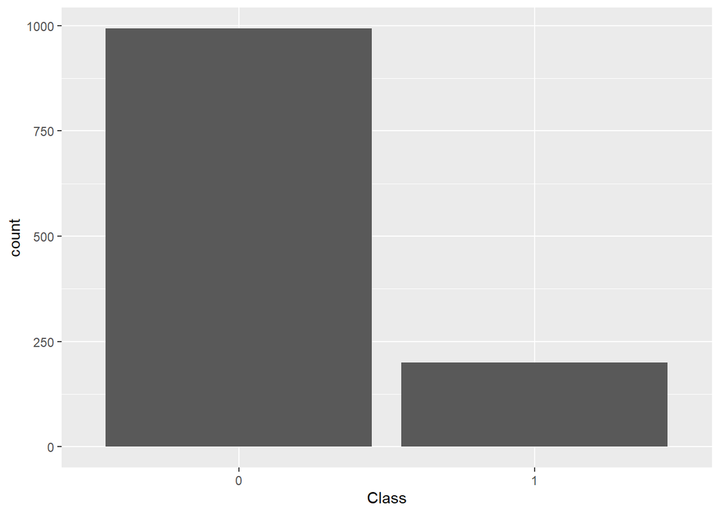

```r
ggplot(data, aes(Class))+geom_bar()
```

보통 10:1 이상 차이가 나는 경우 불균형하다고 판단  
본 시험의 데이터는 원데이터의 일부분을 떼온 데이터인 듯(원데이터의 사기거래 비율은 0.17%)  
위 데이터에 따르면 정상:사기거래가 5:1정도의 거래비율을 보임  
[Time 변수의 거래별 히스토그램]

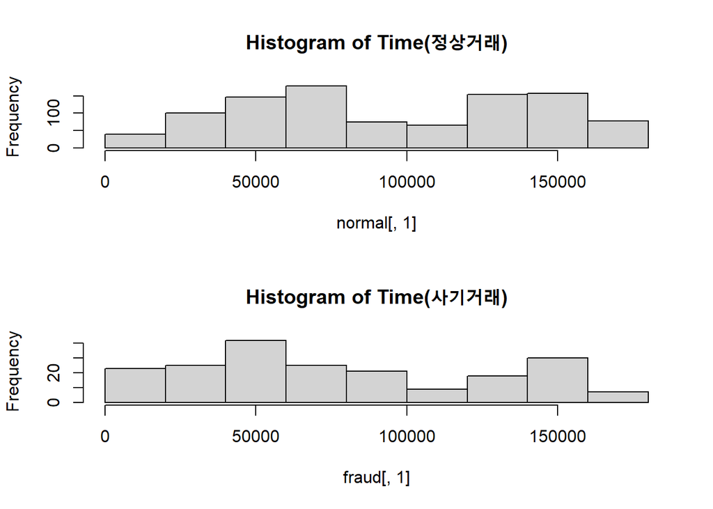

```r
normal<-data %>% dplyr::filter(Class==0)
fraud<-data %>% filter(Class==1)

par(mfrow=c(2,1))
hist(normal[,1], main="Histogram of Time(정상거래)")
hist(fraud[,1], main="Histogram of Time(사기거래)")
```

Time별로 거래를 볼 때, 둘다 쌍봉분포이며 발생시간별로 뜯어봤을 때 약간의 차이가 있다.  
Time변수값의 작음이 이른 시간대에 이뤄진 거래라는 의미라면, 사기거래 분포의 두 봉우리를 봤을 때 사기거래는 늦은 시간보다 이른 시간에 이뤄지는 경우가 많을 것으로 생각된다.  
[V1~V17 변수의 거래별 상자그림]

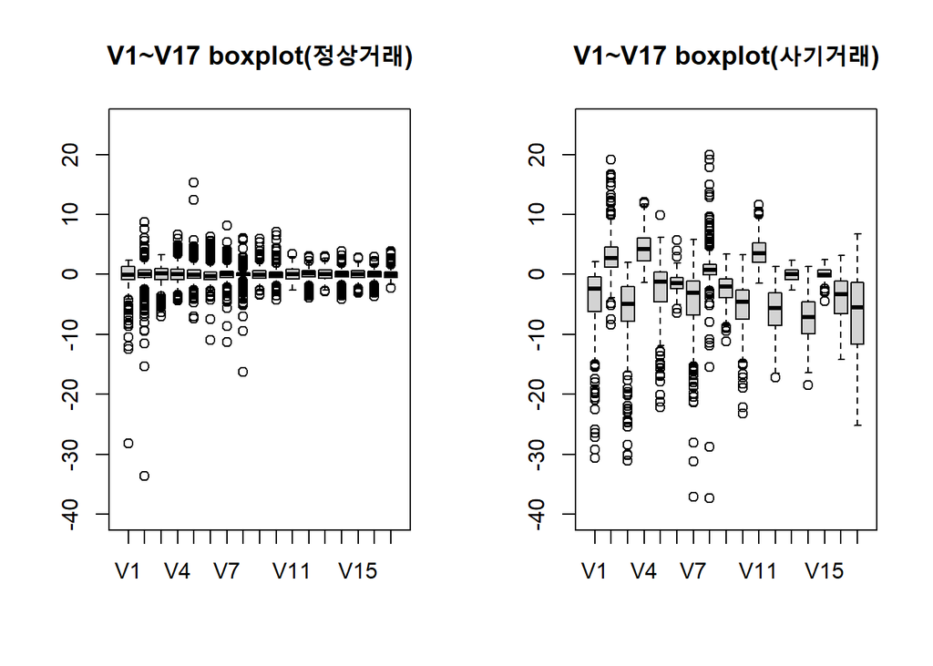

```r
par(mfrow=c(1,2))
boxplot(normal[,2:18], ylim=c(-40,25), main="V1~V17 boxplot(정상거래)")
boxplot(fraud[,2:18], ylim=c(-40,25), main="V1~V17 boxplot(사기거래)")
```

사기거래의 경우 정상거래에 비해 V1~V17변수 산포정도, 그리고 이상치 범위가 넓다.  
중앙값도 일정하지 않음을 상자그림으로 볼 수 있다.  
이상치 유무도 정상/사기거래 분류에 중요하게 작용하는 요인이 될 것같아서 이상치에 대한 별도처리는 하지 않았다.  
[Amount 변수의 거래별 히스토그램]

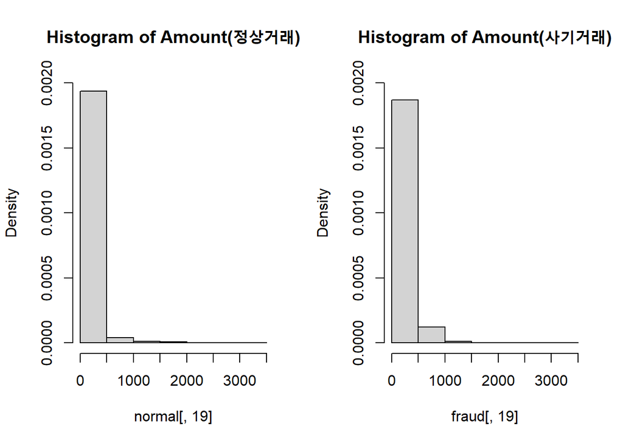

```r
par(mfrow=c(1,2))
hist(normal[,19], breaks=seq(0,3500,500), freq=F, xlim=c(0,3500), ylim=c(0,0.002), main="Histogram of Amount(정상거래)")
hist(fraud[,19], breaks=seq(0,3500,500), freq=F, xlim=c(0,3500), ylim=c(0,0.002), main="Histogram of Amount(사기거래)")
```

두 그룹 비교를 위해 동일한 x축, 그리고 y축은 밀도값으로 비교  
사기거래 건에 대해서 500-1000사이의 거래건의 밀도가 조금 더 높음을 확인 할 수있다.

1.2 변수간 상관관계를 시각화하고 전처리가 필요함을 설명하라

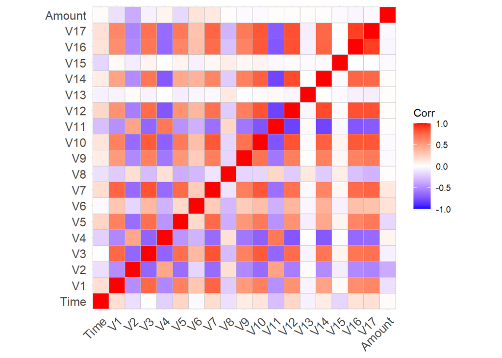

```r
data_cor<-cor(data[,1:19])
ggcorrplot::ggcorrplot(data_cor)
```

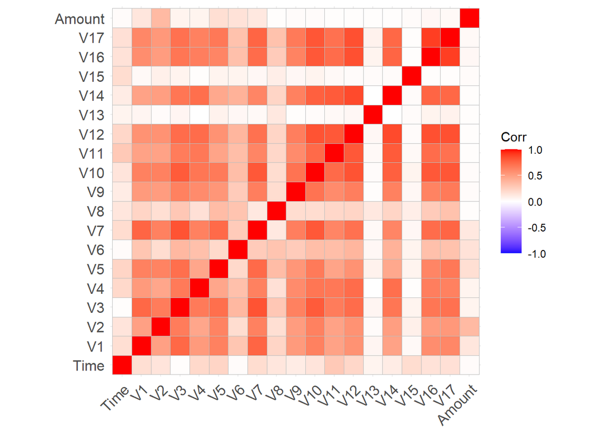

```r
ggcorrplot(abs(data_cor))
```

```r
highcorvar<-caret::findCorrelation(data_cor, cutoff=0.8)
colnames(data[c(highcorvar)])
```

```
## [1] "V10" "V12" "V17" "V3"
```

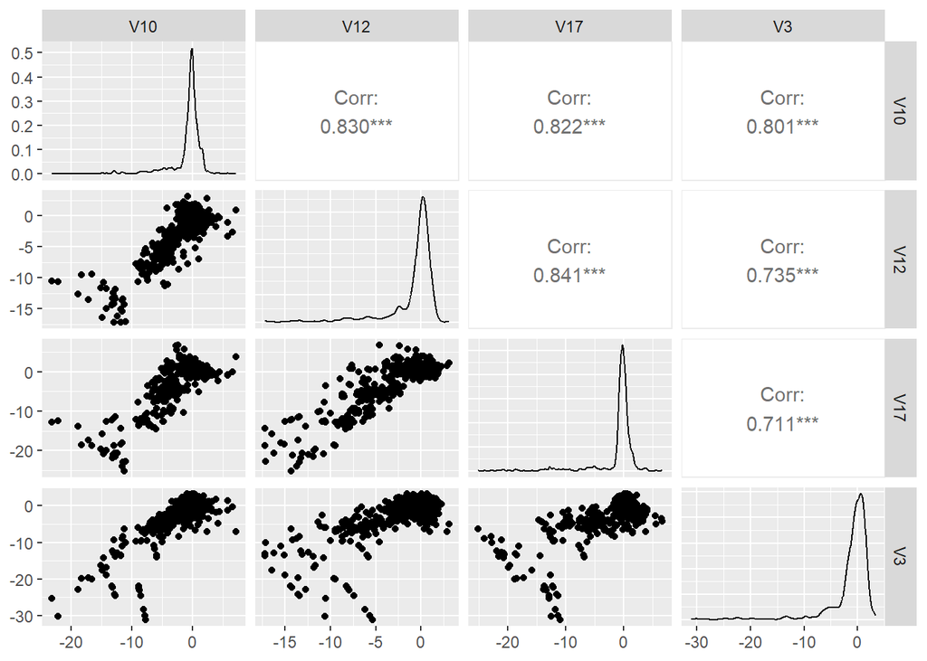

```r
GGally::ggpairs(data[c(highcorvar)])
```

```r
md<-glm(Class ~. , data=data, family="binomial")
car::vif(md)
```

```
##      Time        V1        V2        V3        V4        V5        V6        V7
##  2.002172  8.720532 12.835691  2.657193  3.536170  6.269494  2.971627  3.025842
##        V8        V9       V10       V11       V12       V13       V14       V15
##  3.398172  2.708683  4.765757  1.777157  2.932415  1.231067  3.888810  1.449569
##       V16       V17    Amount
##  2.445622  6.825134  4.497663
```

종속변수 사이 상관성이 꽤 높은 변수쌍이 존재하기 때문에 변수선택이나 차원축소 등의 방법으로 해결해야한다.  
+ 각 변수의 분포가 대부분 오른쪽으로 치우쳐 있는데 이에 대한 전처리는? 필요여부 및 방법

#### Q2

2.1 차원축소 방법 2가지 이상 비교하고 한가지 선택

- 주성분분석PCA
- 선형판별분석LDA
- 특이값분해SCD
- 요인분석FA
- 독립성분분석
- 다차원척도법MDS
- 변수선택법

2.2 추천한 한 가지를 실제로 수행하고 선택한 이유 설명  
[변수선택법]

```r
forw<-glm(Class~1, data=data, family='binomial')
back<-glm(Class~., data=data, family='binomial')
#step(forw, direction= "forward", scope=list(lower=forw, upper=back)) #V14, V4, V12, V8, V10, V16, V1
#step(back, direction= "backward" ) #V1, V4, V8, V10, V12, V14, V16
#step(forw, direction= "both", scope=list(upper=back) ) #V14, V4 V12, V8, V10, V16, V1
sel_v<-c(2,5,9,11,13,15,17)
```

[주성분분석]

```r
# PCA 수행
pca <- prcomp(scale(data[,1:19]), center = TRUE, scale = TRUE)

# 주성분 요약 정보 출력
summary(pca)
```

```
## Importance of components:
##                           PC1     PC2    PC3     PC4     PC5     PC6     PC7
## Standard deviation     3.0468 1.14316 1.1317 1.07382 1.05855 0.97209 0.89201
## Proportion of Variance 0.4886 0.06878 0.0674 0.06069 0.05898 0.04973 0.04188
## Cumulative Proportion  0.4886 0.55734 0.6248 0.68544 0.74441 0.79415 0.83603
##                            PC8    PC9    PC10    PC11    PC12    PC13    PC14
## Standard deviation     0.81641 0.6781 0.65685 0.60730 0.55247 0.46783 0.41636
## Proportion of Variance 0.03508 0.0242 0.02271 0.01941 0.01606 0.01152 0.00912
## Cumulative Proportion  0.87111 0.8953 0.91802 0.93743 0.95349 0.96501 0.97413
##                           PC15    PC16    PC17    PC18    PC19
## Standard deviation     0.37666 0.35300 0.31869 0.27803 0.21472
## Proportion of Variance 0.00747 0.00656 0.00535 0.00407 0.00243
## Cumulative Proportion  0.98160 0.98816 0.99350 0.99757 1.00000
```

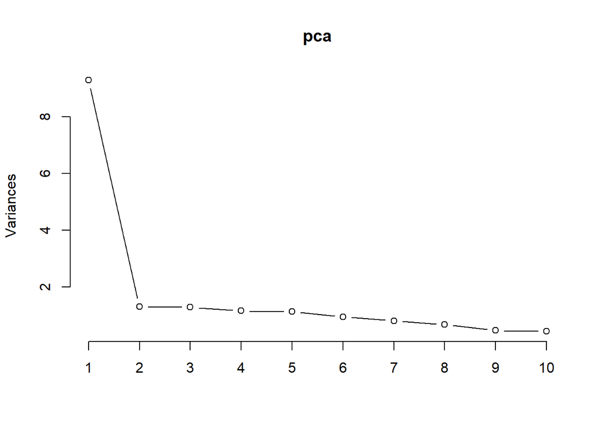

```r
plot(pca, type="l")
```

```r
#pca$rotation[,1:5]
```

screeplot으로는, 2번째 주성분부터 설명력이 급격히 떨어져서…  
Cumulative Proportion값이 0.80이 넘는 7개 주성분을 사용하기로 함.

#### Q3

3.1 장/단점 기술하고, 한 가지 추천

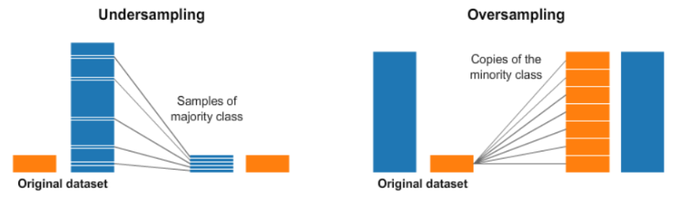

(과소,과대적합 관련 글 출처)  
https://www.kaggle.com/code/rafjaa/resampling-strategies-for-imbalanced-data2sets/notebook  
https://hwi-doc.tistory.com/entry/%EC%96%B8%EB%8D%94-%EC%83%98%ED%94%8C%EB%A7%81Undersampling%EA%B3%BC-%EC%98%A4%EB%B2%84-%EC%83%98%ED%94%8C%EB%A7%81Oversampling

- 언더샘플링: 높은 비율의 데이터를 줄여 데이터 불균형 해소, 학습에 사용되는 데이터 수를 급격히 감소시켜 성능이 떨어질 수 있음
- 오버샘플링: 낮은 비율의 데이터를 늘여 데이터 불균형 해소, 방법이 가능하다면 언더샘플링보다 좋은 방안이 될 수 있으나 어떻게 없던 데이터를 생성하느냐가 문제

3.2 추천한 한 가지를 실제로 수행하고 선택한 이유 설명  
[오버샘플링(SMOTE)]

```r
data1 <- data.frame(data[,sel_v], Class=data$Class)
data2 <- data.frame(pca$x[,1:7], Class=data$Class)

data1_over<-themis::smote(data1, var= "Class", k = 10)
data2_over<-smote(data2, var= "Class", k = 10)
#k: Number of nearest neighbor that are used to generate the new examples of the minority class.

table(data1_over$Class)
```

```
##
##   0   1
## 993 993
```

```r
table(data2_over$Class)
```

```
##
##   0   1
## 993 993
```

변수선택, 주성분분석으로 생성된 새로운 데이터프레임 data1, data2로 각각 smote수행 결과, 사기거래 총993건의 샘플생성 완료  
3.3 현재까지 전처리한 데이터를 통해 모델 수행 후 결과 분석

```r
# 데이터셋 분할
set.seed(123)
train_index <- sample(nrow(data2), 0.7*nrow(data2))

train_data1 <- data1_over[train_index, ]
test_data1 <- data1_over[-train_index, ]

train_data2 <- data2_over[train_index, ]
test_data2 <- data2_over[-train_index, ]
```

[변수선택&SMOTE 결과로 RandomForest수행]

```r
# 변수선택 결과로 Random Forest
rf_model1 <- randomForest::randomForest(Class ~ ., data=train_data1)

# 검증용 데이터셋으로 예측
rf_pred1 <- predict(rf_model1, newdata=test_data1)
rf_pred_prob1 <- predict(rf_model1, newdata=test_data1, type="prob")

caret::confusionMatrix(rf_pred1, test_data1$Class)[2]
```

```
## $table
##           Reference
## Prediction   0   1
##          0 306  99
##          1   1 745
```

```r
confusionMatrix(rf_pred1, test_data1$Class)[4]
```

```
## $byClass
##          Sensitivity          Specificity       Pos Pred Value
##            0.9967427            0.8827014            0.7555556
##       Neg Pred Value            Precision               Recall
##            0.9986595            0.7555556            0.9967427
##                   F1           Prevalence       Detection Rate
##            0.8595506            0.2667246            0.2658558
## Detection Prevalence    Balanced Accuracy
##            0.3518679            0.9397220
```

[주성분분석&SMOTE 결과로 RandomForest수행]

```r
# 주성성분 결과로 Random Forest
rf_model2 <- randomForest(Class ~ ., data=train_data2)

# 검증용 데이터셋으로 예측
rf_pred2 <- predict(rf_model2, newdata=test_data2)
rf_pred_prob2 <- predict(rf_model2, newdata=test_data2, type="prob")

confusionMatrix(rf_pred2, test_data2$Class)[2]
```

```
## $table
##           Reference
## Prediction   0   1
##          0 304 103
##          1   3 741
```

```r
confusionMatrix(rf_pred2, test_data2$Class)[4]
```

```
## $byClass
##          Sensitivity          Specificity       Pos Pred Value
##            0.9902280            0.8779621            0.7469287
##       Neg Pred Value            Precision               Recall
##            0.9959677            0.7469287            0.9902280
##                   F1           Prevalence       Detection Rate
##            0.8515406            0.2667246            0.2641182
## Detection Prevalence    Balanced Accuracy
##            0.3536056            0.9340950
```

[두 모델에 대한 ROC곡선]

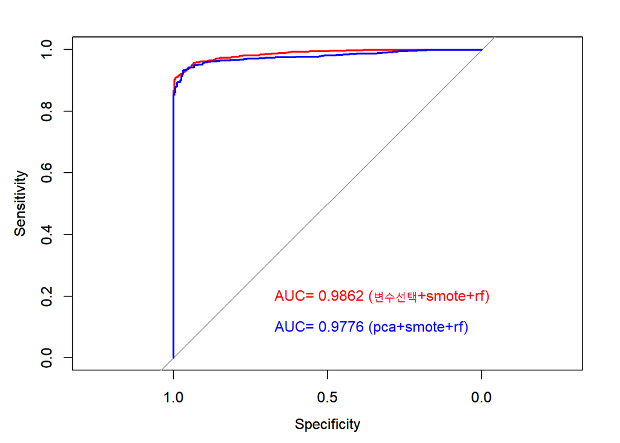

```r
roc_obj1<- pROC::roc(test_data1$Class, rf_pred_prob1[,2])
auc1<-auc(roc_obj1)
roc_obj2<- roc(test_data2$Class, rf_pred_prob2[,2])
auc2<-auc(roc_obj2)

plot(roc_obj1, col="red")
par(new=TRUE)
plot(roc_obj2, col="blue")
text(0.7,0.2,paste("AUC=", round(auc1,4), "(변수선택+smote+rf)"), col="red", pos=4)
text(0.7,0.1,paste("AUC=", round(auc2,4), "(pca+smote+rf)"), col="blue", pos=4)
```

#### Q4

4.1 이상탐지 모델 2가지 이상 기술, 장단점 설명

✅ 이상탐지(anomaly detection) 모델: 이상탐지 모델은 주로 비지도학습(unsupervised learning) 알고리즘을 사용하여 데이터의 패턴을 학습하고 이를 기반으로 이상치를 감지하는 모델  
**One-Class SVM**  
장점1. 높은 성능을 보이며 이상치 탐지에 적합합니다.  
단점1. 이상치가 초평면(hyperplane)을 벗어나는 경우, 잘못된 분류를 할 가능성이 있습니다.  
단점2. 매개변수 설정에 따라 결과가 크게 달라질 수 있습니다.  
**Isolation Forest**  
장점1. 높은 성능을 보여 이상치 탐지에 적합합니다.  
장점2. 계산 비용이 낮아 대규모 데이터에 적용하기 용이합니다.  
장점3. 과적합(overfitting) 문제가 발생하지 않습니다.  
단점1. 특정 조건에서는 LOF보다 성능이 떨어질 수 있습니다.  
단점2. 매개변수 설정에 따라 결과가 크게 달라질 수 있습니다.  
**LOF**  
장점1. 높은 성능을 보여 이상치 탐지에 적합합니다.  
장점2. 이상치 탐지 외에도 군집(clustering) 문제에서도 사용됩니다.  
장점3. 이상치 탐지 알고리즘 중에서 계산 비용이 비교적 낮습니다.  
단점1. 데이터셋이 매우 밀집하거나 데이터셋의 차원이 높을 경우 성능이 떨어질 수 있습니다.  
단점2. 매개변수 설정에 따라 결과가 크게 달라질 수 있습니다.

4.2 전처리한 데이터로 1가지 이상 탐지 모델을 구현하고, 3번 결과와 비교  
[SVM 이상치탐지]

```r
set.seed(123)
svm_model <- e1071::svm(Class ~ ., data = train_data1)
svm_pred <- predict(svm_model, newdata = test_data1)

confusionMatrix(svm_pred, test_data2$Class)[2]
```

```
## $table
##           Reference
## Prediction   0   1
##          0 306 117
##          1   1 727
```

```r
confusionMatrix(svm_pred, test_data2$Class)[4]
```

```
## $byClass
##          Sensitivity          Specificity       Pos Pred Value
##            0.9967427            0.8613744            0.7234043
##       Neg Pred Value            Precision               Recall
##            0.9986264            0.7234043            0.9967427
##                   F1           Prevalence       Detection Rate
##            0.8383562            0.2667246            0.2658558
## Detection Prevalence    Balanced Accuracy
##            0.3675065            0.9290585
```

[one-class SVM 이상치탐지]

```r
set.seed(123)
normal1<-data1 %>% filter(Class==0)
ocsvm_model <- e1071::svm(normal1[,1:7], type = 'one-classification', nu = 0.5)
ocsvm_pred <- predict(ocsvm_model, newdata = test_data1[,1:7])

ocsvm_pred <- as.factor(as.integer(ocsvm_pred))
confusionMatrix(ocsvm_pred, test_data1$Class)[2]
```

```
## $table
##           Reference
## Prediction   0   1
##          0 154 822
##          1 153  22
```

```r
confusionMatrix(ocsvm_pred, test_data1$Class)[4]
```

```
## $byClass
##          Sensitivity          Specificity       Pos Pred Value
##           0.50162866           0.02606635           0.15778689
##       Neg Pred Value            Precision               Recall
##           0.12571429           0.15778689           0.50162866
##                   F1           Prevalence       Detection Rate
##           0.24006235           0.26672459           0.13379670
## Detection Prevalence    Balanced Accuracy
##           0.84795830           0.26384751
```

4.3 데이터분석과 관점에서 3번에서 만든 모델과 4번에서 만든 모델 설명

[output not shown]

### [통계]

#### Q5

2년 전 제품 생산량이 100,000개, 1년 전 제품 생산량이 150,000개, 그 후 팩토리 기술의 상승으로 제품 생산량이 250,000개 되었을 때, 연평균 상승률의 대푯값을 구하시오. (반올림하여 소수점 아래 둘째자리까지 표기하시오.)

- 기하 평균(Geometric Mean) - psych::geometric.mean()
- 조화 평균(Harmonic Mean) - psych::harmonic.mean()

```r
library(psych)
round(geometric.mean(c(1+(15-10)/10, 1+(25-15)/15)),4)
```

```
## [1] 1.5811
```

(개념 출처)  
https://ballpen.blog/%EC%82%B0%EC%88%A0-%EA%B8%B0%ED%95%98-%EC%A1%B0%ED%99%94-%ED%8F%89%EA%B7%A0-%EA%B0%9C%EB%85%90-%ED%99%9C%EC%9A%A9/#2  
(코드관련 출처)  
https://2stndard.tistory.com/138

#### Q6

12건의 광고 시간 측정. 평균 15.5초, 분산 3.2초 일때 90% 신뢰구간은?

```r
m<-15.5; v<-3.2; n<-12
m + c(-1,1) * qt(0.95, 11) * sqrt(v/n)
```

```
## [1] 14.57261 16.42739
```

#### Q7

강의 상류와 하류의 생물 다양성 점수에 차이가 있는지 검정하시오. (단, 같은 강에서 상하류는 서로 독립적이지 않으며, 종속적인 관계에 있다.)  
7.1 귀무가설과 대립가설을 세우시오  
=> 귀무가설: 상하류에 점수차이가 없다, 대립가설: 상하류에 점수차이가 있다.  
7.2 검정 통계량과 유의 확률을 구하고, 연구가설 채택여부를 검정하시오.  
*대응표본의 전제조건: 표본차가 정규분포를 따라야 함

```r
data7<-read.csv('https://raw.githubusercontent.com/Datamanim/datarepo/main/adp/27/river.csv')
head(data7)
```

```
##   River   up down
## 1     A 57.1 45.7
## 2     B 51.6 37.2
## 3     C 53.9 53.3
## 4     D 59.0 54.3
## 5     E 57.5 46.3
## 6     F 46.1 61.3
```

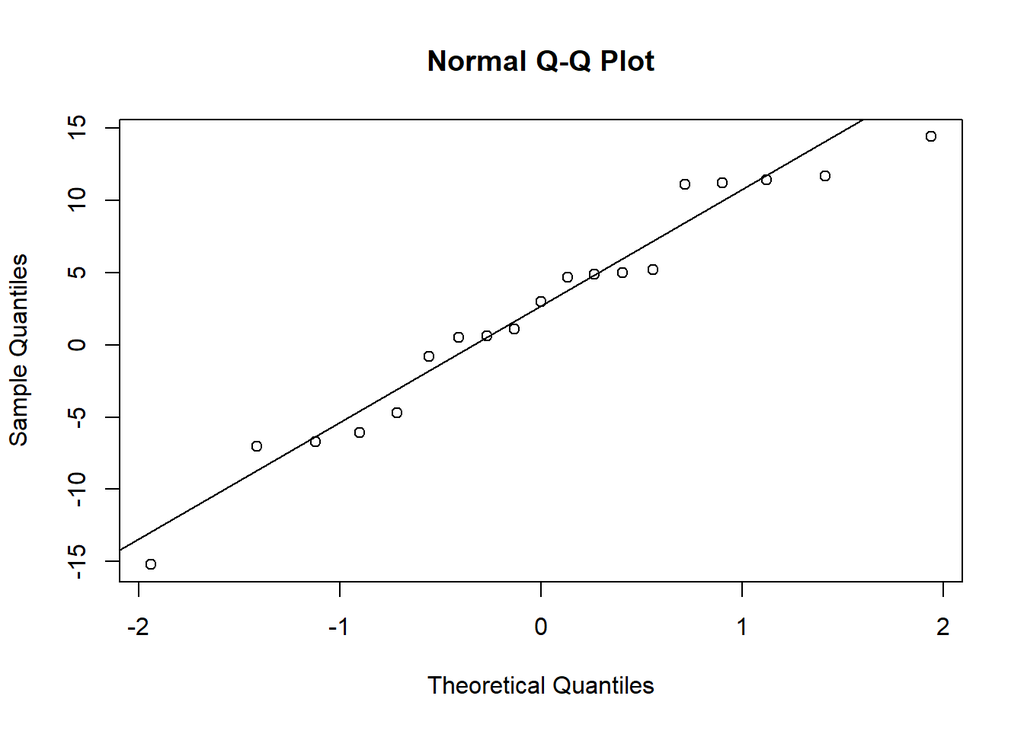

```r
qqnorm(data7[,2]-data7[,3]);qqline(data7[,2]-data7[,3])
```

```r
shapiro.test(data7[,2]-data7[,3]) #정규분포 만족
```

```
##
##  Shapiro-Wilk normality test
##
## data:  data7[, 2] - data7[, 3]
## W = 0.95541, p-value = 0.4858
```

```r
t.test(data7$up, data7$down, paired=T)
```

```
##
##  Paired t-test
##
## data:  data7$up and data7$down
## t = 1.2922, df = 18, p-value = 0.2126
## alternative hypothesis: true mean difference is not equal to 0
## 95 percent confidence interval:
##  -1.459150  6.122308
## sample estimates:
## mean difference
##        2.331579
```

=> 검정통계량: 1.2922, 유의확률: 0.2126, 대립가설을 채택하지 않는다. 상하류차이 없음.

cf. 비모수검정  
- Mann-Whitney U (two sample)  
- Wilcoxon signed rank test (paired test)

```r
wilcox.test(data7$up, data7$down, paired=T)
```

```
##
##  Wilcoxon signed rank test with continuity correction
##
## data:  data7$up and data7$down
## V = 125.5, p-value = 0.2273
## alternative hypothesis: true location shift is not equal to 0
```

ties로 인한 오류 해결법 => ‘exact’ 인자

```r
wilcox.test(data7$up, data7$down, paired=T, exact=F)
```

```
##
##  Wilcoxon signed rank test with continuity correction
##
## data:  data7$up and data7$down
## V = 125.5, p-value = 0.2273
## alternative hypothesis: true location shift is not equal to 0
```

#### Q8

8.1 분위수 회귀분석 (Quantile Regression) 을 사용하여 회귀 계수를 구하시오. (반올림하여 소수점 아래 둘째자리까지 표기하시오.)

```r
data8<-read.csv('https://raw.githubusercontent.com/Datamanim/datarepo/main/adp/27/problem8.csv')
head(data8)
```

```
##   temperature  wind precipitation user_counts
## 1   10.400000 4.600   0.844943820        6368
## 2    5.666667 4.625   0.040860215        5902
## 3    4.933333 4.725   0.008695652        6226
## 4    3.400000 2.675   0.156989247        5829
## 5    8.900000 3.950   7.988461538        7589
## 6    9.066667 3.450   0.040860215        9271
```

```r
qr<-quantreg::rq(user_counts~., data=data8)
round(qr$coefficients,2)
```

```
##   (Intercept)   temperature          wind precipitation
##       5941.84        268.89       -129.41        -83.38
```

8.2 8.1의 모델의 회귀계수를 활용하여 temperature : 10.5 , wind : 8.2 , precipitation : 3.5 일때 user_counts를 예측하시오

```r
round(predict(qr, newdata=data.frame(temperature=10.5, wind=8.2, precipitation=3.5)),0)
```

```
##    1
## 7412
```

#### Q9

지하철 라인(line), 월(month), 상호작용이 전체이용자수(total)에 영향을 주는지 분석하시오. (단 제곱합은 Type3 를 이용)

9.1 귀무가설과 대립가설 설정하라  
=> 귀무, 대립가설: 지하철라인, 월, 상호작용에 따른 전체이용자수 차이가 없다, 하나라도 차이가 있다  
9.2 통계량을 구하고, 대립가설 채택여부를 기술하라

```r
setwd("C:/Users/user/Desktop/27")
data9<-read.csv("subway.csv")
str(data9)
```

```
## 'data.frame':    72 obs. of  3 variables:
##  $ line : int  1 1 1 1 1 1 1 1 1 1 ...
##  $ month: int  1 2 3 4 5 6 7 8 9 10 ...
##  $ total: int  1310 1300 1305 1200 1301 1304 1330 1230 1330 1330 ...
```

```r
data9$line <- factor(data9$line)
data9$month <- factor(data9$month)
str(data9)
```

```
## 'data.frame':    72 obs. of  3 variables:
##  $ line : Factor w/ 3 levels "1","2","3": 1 1 1 1 1 1 1 1 1 1 ...
##  $ month: Factor w/ 12 levels "1","2","3","4",..: 1 2 3 4 5 6 7 8 9 10 ...
##  $ total: int  1310 1300 1305 1200 1301 1304 1330 1230 1330 1330 ...
```

```r
model9<-lm(total~line + month + line*month, data=data9)
car::Anova(model9, type="III")
```

```
## Anova Table (Type III tests)
##
## Response: total
##              Sum Sq Df   F value    Pr(>F)
## (Intercept) 3466345  1 33455.336 < 2.2e-16 ***
## line         133663  2   645.023 < 2.2e-16 ***
## month         39425 11    34.592 7.896e-16 ***
## line:month    96969 22    42.541 < 2.2e-16 ***
## Residuals      3730 36
## ---
## Signif. codes:  0 '***' 0.001 '**' 0.01 '*' 0.05 '.' 0.1 ' ' 1
```

```r
#cf.
table(data9$line, data9$month)
```

```
##
##     1 2 3 4 5 6 7 8 9 10 11 12
##   1 2 2 2 2 2 2 2 2 2  2  2  2
##   2 2 2 2 2 2 2 2 2 2  2  2  2
##   3 2 2 2 2 2 2 2 2 2  2  2  2
```

```r
model9_1<-lm(total~line + month + line*month, data=data9)
anova(model9_1)
```

```
## Analysis of Variance Table
##
## Response: total
##            Df  Sum Sq Mean Sq   F value    Pr(>F)
## line        2 2147444 1073722 10362.998 < 2.2e-16 ***
## month      11   32065    2915    28.134 2.103e-14 ***
## line:month 22   96969    4408    42.541 < 2.2e-16 ***
## Residuals  36    3730     104
## ---
## Signif. codes:  0 '***' 0.001 '**' 0.01 '*' 0.05 '.' 0.1 ' ' 1
```

```r
model9_2<-lm(total~line*month, data=data9)
anova(model9_2)
```

```
## Analysis of Variance Table
##
## Response: total
##            Df  Sum Sq Mean Sq   F value    Pr(>F)
## line        2 2147444 1073722 10362.998 < 2.2e-16 ***
## month      11   32065    2915    28.134 2.103e-14 ***
## line:month 22   96969    4408    42.541 < 2.2e-16 ***
## Residuals  36    3730     104
## ---
## Signif. codes:  0 '***' 0.001 '**' 0.01 '*' 0.05 '.' 0.1 ' ' 1
```

=> line, month, line:month 모두 전체 이용자수에 유효한 영향을 미친다.  
(Q9관련 출처)  
https://communities.sas.com/t5/SAS-Tech-Tip/SAS-University-Edition-%EB%B6%88%EA%B7%A0%ED%98%95%EC%9E%90%EB%A3%8C-%EB%B6%84%EC%82%B0%EB%B6%84%EC%84%9D-Unbalanced-ANOVA/ta-p/654848  
(실기대비관련 출처)  
https://lovelydiary.tistory.com/381  
https://it-freelancer.tistory.com/category/ADP%20%28R%29